# Taller RMarkdown

Cristal Rivera Picado

2 de septiembre de 2020

Para este taller vamos aprender a como realizar reportes mediante R Markdown

Cuando echo = False en el chunk indica que este no imprime el codigo que se escribe para tener un output(por ejemplo un grafico)

## R Markdown

#0. Instalacion R Markdown

Este comando es para instalar paquetes especificos de R, tambien puede hacerse desde la el cuadro de la derecha en Paquetes luego ir a instalar y elegir el paquete que se desea instalar.

```r
#install.packages("rmarkdown")
```

#1. Cargar librerias

```r
library(prettydoc)
library(rmarkdown)
library(tidyverse)
library(tidyr)             #Manipulacion de los datos
library(readr)
library(dplyr)
library(lubridate) #para trabajar fechas
```

```r
library(ggplot2) # para los graficos
library(forecast)#predicciones
```

#2. Importacion de datos

```r
por_dia_ruta27.csv<- read_csv("por_dia_ruta27.csv")
por_dia_ruta27.csv <- as.data.frame(por_dia_ruta27.csv)
View(por_dia_ruta27.csv)#para que sea un marco de datos
```

#3. Analisis Exploratorio

```r
summary(por_dia_ruta27.csv)
```

```
##   PuntoConteo        Dia               Liviano         Autobuses
##  Min.   :  500   Length:10851       Min.   :  1554   Min.   :   14.0
##  1st Qu.: 2900   Class :character   1st Qu.: 20158   1st Qu.:  334.0
##  Median : 7100   Mode  :character   Median : 38769   Median :  461.0
##  Mean   :12215                      Mean   : 50870   Mean   :  741.3
##  3rd Qu.:22450                      3rd Qu.: 75256   3rd Qu.:  893.0
##  Max.   :30620                      Max.   :234080   Max.   :34176.0
##                                     NA's   :2        NA's   :2
##       C23E             C4E              C5E
##  Min.   :   9.0   Min.   :  11.0   Min.   :   9.0
##  1st Qu.: 421.0   1st Qu.: 213.0   1st Qu.: 597.0
##  Median : 637.0   Median : 501.0   Median : 938.0
##  Mean   : 710.9   Mean   : 535.8   Mean   : 879.8
##  3rd Qu.: 913.0   3rd Qu.: 775.0   3rd Qu.:1124.0
##  Max.   :4020.0   Max.   :5705.0   Max.   :3895.0
##  NA's   :2        NA's   :2        NA's   :2
```

eliminar NA´s

```r
ruta27 <- por_dia_ruta27.csv %>%   #pipe
                  drop_na()        #elimina los NA´S
summary(ruta27)
```

```
##   PuntoConteo        Dia               Liviano         Autobuses
##  Min.   :  500   Length:10849       Min.   :  1554   Min.   :   14.0
##  1st Qu.: 2900   Class :character   1st Qu.: 20158   1st Qu.:  334.0
##  Median : 7100   Mode  :character   Median : 38769   Median :  461.0
##  Mean   :12214                      Mean   : 50870   Mean   :  741.3
##  3rd Qu.:22450                      3rd Qu.: 75256   3rd Qu.:  893.0
##  Max.   :30620                      Max.   :234080   Max.   :34176.0
##       C23E             C4E              C5E
##  Min.   :   9.0   Min.   :  11.0   Min.   :   9.0
##  1st Qu.: 421.0   1st Qu.: 213.0   1st Qu.: 597.0
##  Median : 637.0   Median : 501.0   Median : 938.0
##  Mean   : 710.9   Mean   : 535.8   Mean   : 879.8
##  3rd Qu.: 913.0   3rd Qu.: 775.0   3rd Qu.:1124.0
##  Max.   :4020.0   Max.   :5705.0   Max.   :3895.0
```

```r
#View(ruta27)
```

Un aspecto importante para considerar es que los graficos que se vayan generando se pueden personalizar con los colores que mas se adecuen a lo que se quiere mostrar. Puedes ver los diferentes colores que ofrece ggplot acá: http://sape.inf.usi.ch/quick-reference/ggplot2/colour

Respuestas al punto 4)

1. Primero debemos de preparar el acomodo de los datos por tipo de vehiculo y cantidad para que se acople al grafico que deseamos. Revisar funcion gather https://www.rdocumentation.org/packages/tidyr/versions/0.8.3/topics/gather

```r
ruta27_tipo_veh_1 <- ruta27 %>%
                            gather("Tipo_Vehiculo", "Cantidad",-c(1,2))
View(ruta27_tipo_veh_1)
```

Realizamos la suma total por tipo de vehiculo

```r
ruta27_tipo_veh <- ruta27_tipo_veh_1 %>%
  group_by(Tipo_Vehiculo) %>%
  summarize(Total= sum(Cantidad))
View(ruta27_tipo_veh)
```

Sin anotaciones

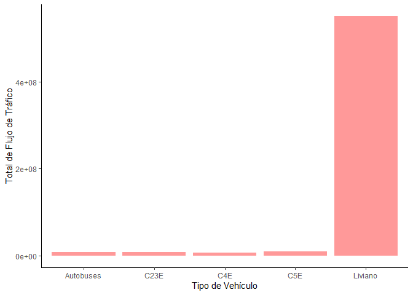

```r
ggplot(ruta27_tipo_veh, aes(x=Tipo_Vehiculo, y= Total)) + geom_bar(stat="identity", fill="#FF9999")+
  labs(x="Tipo de Vehículo", y = "Total de Flujo de Tráfico")+
  theme(panel.grid.major = element_blank(), panel.grid.minor = element_blank(),
panel.background = element_blank(),axis.line = element_line(colour = "black"))
```

Con anotaciones

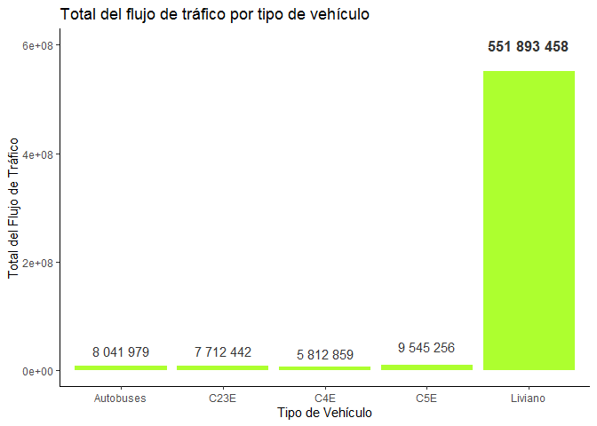

```r
ggplot(ruta27_tipo_veh, aes(x=Tipo_Vehiculo, y= Total)) + geom_bar(stat="identity", fill="greenyellow")+
  labs(x="Tipo de Vehículo", y = "Total del Flujo de Tráfico")+
  annotate("text", x="Liviano", y = 600000000, label = "551 893 458",fontface="bold",size=4.5,color="grey21")+
  annotate("text", x="C5E", y = 43000000, label = "9 545 256",color="grey21")+
  annotate("text", x="C4E", y = 30000000, label = "5 812 859",color="grey21")+
  annotate("text", x="C23E", y = 35500000, label = "7 712 442",color="grey21")+
  annotate("text", x="Autobuses", y = 35000000, label = "8 041 979",color="grey21")+

  theme(panel.grid.major = element_blank(), panel.grid.minor = element_blank(),
panel.background = element_blank(),axis.line = element_line(colour = "black"))+
  ggtitle("Total del flujo de tráfico por tipo de vehículo")
```

2. Distribuciones

Utilizamos un histograma y funcion de densidad para visualizar la distrubucion. Ademas se utiliza una funcion que se llama facet wrap la cual es la que hace que se me separa diferentes graficos en uno solo. Tambien existe la funcion facet grid.

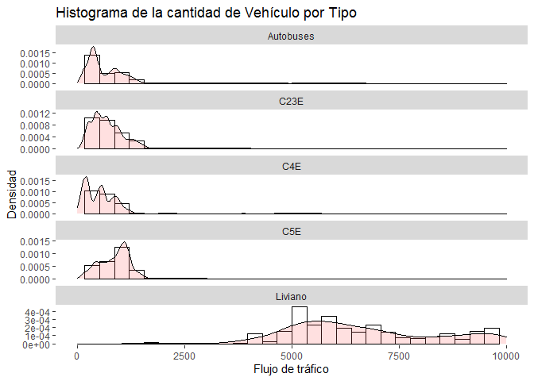

```r
 ggplot(ruta27_tipo_veh_1, aes(x=Cantidad)) +
 geom_histogram(aes(y=..density..), colour="black", fill="white")+
 geom_density(alpha=.2, fill="#FF6666") +
  labs(title="Histograma de la cantidad de Vehículo por Tipo",x="Flujo de tráfico", y ="Densidad")+
  facet_wrap( ~ Tipo_Vehiculo, ncol=1,scales="free_y") + #se ajusta libremente el eje y
  scale_x_continuous(limit = c(0,10000))+  #se puede adecuar el limite para mostrar la distribucion
  theme(panel.grid.major = element_blank(), panel.grid.minor = element_blank(),
  panel.background = element_blank())
```

3. Puntos de conteo, se selecciona el vehiculo liviano.

```r
CantLiv <- ruta27_tipo_veh_1 %>%
  filter(Tipo_Vehiculo=="Liviano")

CantLiv$PuntoConteo <-  as.factor(CantLiv$PuntoConteo) #convertimos al punto de conteo en factor,esto se realiza para posteriormente ordenarlos con la funcion fct_level
#View(CantLiv)
```

Se coloca este comando cuando en ocasiones el group_by no funciona

```r
#detach(package:plyr)
```

```r
pc <- CantLiv %>%
  group_by(PuntoConteo) %>%
  summarize(sumaVehiculos=sum(Cantidad))
#View(pc)
```

Highlight

```r
x <- pc %>% mutate( ToHighlight = ifelse( PuntoConteo == "2900" | PuntoConteo == "10540" | PuntoConteo == "7100" , "yes", "no" ) )
#View(x)
```

Ordenar factor de punto conteo

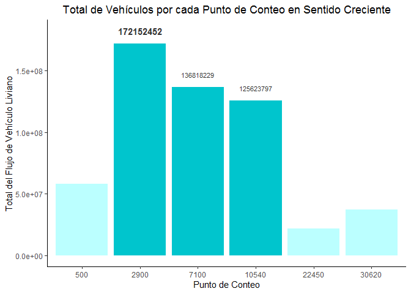

```r
order <- x %>%
  mutate(PuntoConteo = fct_relevel(PuntoConteo,
            "500", "2900", "7100",
            "10540", "22450","30620"))

 ggplot (data=order ,aes(x=PuntoConteo, y=sumaVehiculos,fill=ToHighlight)) +
    geom_bar( stat="identity")+
  scale_fill_manual( values = c( "yes"="turquoise3" ,"no"="paleturquoise1"), guide = FALSE )+
   ggtitle("Total de Vehículos por cada Punto de Conteo en Sentido Creciente") +
  theme(plot.title = element_text(hjust = 0.5))+
   labs(x="Punto de Conteo", y = "Total del Flujo de Vehículo Liviano")+theme(panel.grid.major = element_blank(), panel.grid.minor = element_blank(),
panel.background = element_blank(),axis.line = element_line(colour = "black"))+


   #lo siguiente se realiza de forma automatizada (escribir el numero y la posicion), esto se realiza ya que puede ser que los datos cambien, de lo contrario tendriamos que estar digitando el numero que corresponde.
  annotate("text", x="2900", y = (as.numeric(order[2,2])+10000000) , label = as.character(order[2,2]),fontface="bold",size=4,color="grey21")+
  annotate("text", x="7100", y = (as.numeric(order[3,2])+10000000), label = as.character(order[3,2]),color="grey21",size=3)+
  annotate("text", x="10540", y =(as.numeric(order[4,2])+10000000), label = as.character(order[4,2]),color="grey21",size=3)
```

4. Para el punto de conteo 2900 Analisis de series de tiempo

```r
ruta27_2900 <- ruta27 %>%
                      filter(PuntoConteo == "2900")
#View(ruta27_2900)
```

Trabajando con fechas

```r
ruta27_2900 <- ruta27_2900 %>%
  mutate(Fecha = as.POSIXct(ruta27_2900$Dia, format= "%d/%m/%Y",origin= "01/01/2015"))
```

Análisis por Mes Crear columnas con número de mes y nombre de mes: con comando para que salga en español

```r
meses_2900 <- ruta27_2900%>%
  mutate(Mes=month(Fecha,abbr = TRUE,label=TRUE,locale=Sys.setlocale(category = "LC_COLLATE", locale = "Spanish")),Ano=year(Fecha))
#View(meses_2900)
```

Una vez que tenemos las columnas con MES entonces se crea el data frame acomodandoló mensualemente para que el análisis se haga correctamente.

```r
#detach(package:plyr)
```

```r
meses_2900 <- meses_2900 %>%
  group_by(Ano,Mes) %>%
  summarise (sumaLiviano =sum(Liviano))
#meses_2900
```

```r
meses_sumliv_2900<- meses_2900[,3]
```

Series de tiempo

```r
meses.ts_2900 = ts(meses_sumliv_2900, start = c(2015,2), frequency = 12)
```

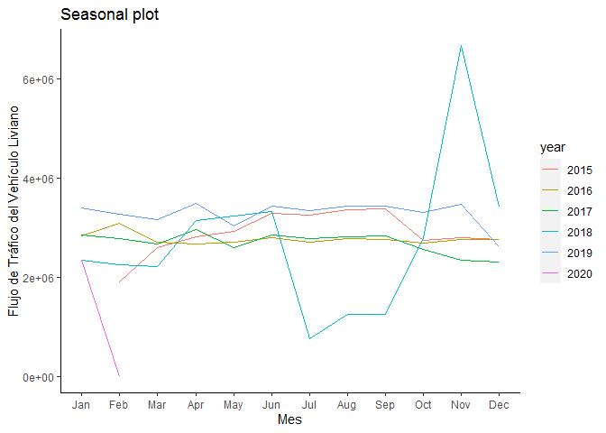

```r
ggseasonplot(meses.ts_2900) + ylab("Flujo de Tráfico del Vehículo Liviano") + xlab("Mes")+
  theme(panel.grid.major = element_blank(), panel.grid.minor = element_blank(),
panel.background = element_blank(),axis.line = element_line(colour = "black"))+
  ggtitle ("Seasonal plot")
```